```
                     # veille technologique sur le module pyplot de la bibliothèque matplotlib
```

# Qu’est ce que c’est Matplotlib ?

Matplotlib est un package (c’est-à-dire un regroupement de plusieurs modules) qui sert à la création de graphiques Python.

# Pyplot

C'est un module du package matplotlib de python qui contient des fonctions qui permettent de realiser des graphiques sans taper des lignes de codes super complexe :

# Quelques fonctions du module pyplot

scatter(x, y) : affiche un graphique à points entre x et y

plot(x, y) : affiche un graphique ligne entre x et y

hist(x) : affiche un histogramme de x.

et plein d'autre

### Lineplot

Pour juste tracer une courbe

pour tracer une courbe par colonne : pyplot.plot(df)

pour tracer une courbe par ligne : pyplot.plot(df.T) (on transpose le dataframe).

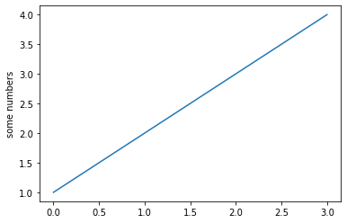

```python
#Exemple:
import numpy as np
import matplotlib.pyplot as plt
plt.plot([1, 2, 3, 4])
plt.ylabel('some numbers')
plt.show()
```

### Barplot

construction de diagrame en bare.

pypot.bar

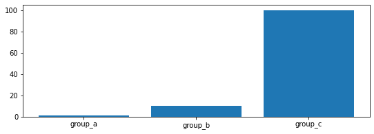

```python
#Exemple:
names = ['group_a', 'group_b', 'group_c']
values = [1, 10, 100]

plt.figure(figsize=(9, 3))
plt.bar(names, values)
plt.show()
```

### Barres d erreur

On peut rajouter des barres d'erreur sur nos barplot

pyplot.errorbar

```
<ErrorbarContainer object of 3 artists>
```

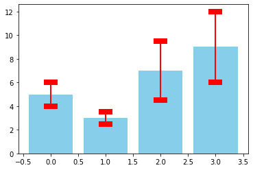

```python
#Exemple:
values = [5, 3, 7, 9]
errorValues = [1, 0.5, 2.5, 3]
plt.bar(range(len(values)), values, color = 'skyblue')
plt.errorbar(range(len(values)), values, yerr = errorValues,
    fmt = 'none', capsize = 10, ecolor = 'red', elinewidth = 2, capthick = 8)
```

### Scatter plot

Scatter plot (nuage de points)

pyplot.scarter

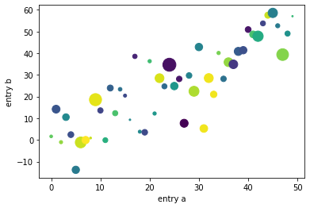

```python
#Exemple:
data = {'a': np.arange(50),
        'c': np.random.randint(0, 50, 50),
        'd': np.random.randn(50)}
data['b'] = data['a'] + 10 * np.random.randn(50)
data['d'] = np.abs(data['d']) * 100

plt.scatter('a', 'b', c='c', s='d', data=data)
plt.xlabel('entry a')
plt.ylabel('entry b')
plt.show()
```

### Histogramme

Pour la construction d'histogramme

pyplot.hist

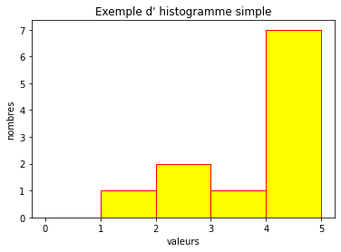

```python
#Exemple:
x = [1, 2, 2, 3, 4, 4, 4, 4, 4, 5, 5]
plt.hist(x, range = (0, 5), bins = 5, color = 'yellow',
            edgecolor = 'red')
plt.xlabel('valeurs')
plt.ylabel('nombres')
plt.title('Exemple d\' histogramme simple')
```

### Boxplot

Construction de boxplot (ou boîte à moustache)

pyplot.boxplot

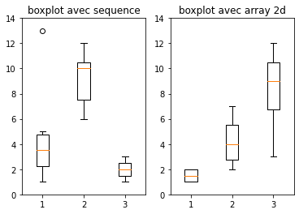

```python
#Exemple:
plt.subplot(121)
plt.boxplot([[1, 2, 3, 4, 5, 13], [6, 7, 8, 10, 10, 11, 12], [1, 2, 3]])
plt.ylim(0, 14)
plt.title('boxplot avec sequence')

plt.subplot(122)
plt.boxplot(np.array([[1, 2, 3], [2, 7, 8], [1, 3, 10], [2, 5, 12]]))
plt.ylim(0, 14)
plt.title('boxplot avec array 2d')
```

### Pie

Construction de diagramme circulaire

pyplot.pie

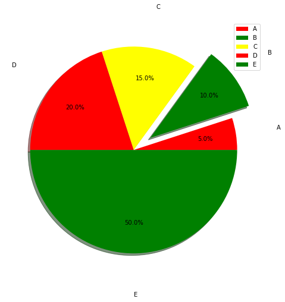

```python
#Exemple:
plt.figure(figsize = (8, 8))
x = [1, 2, 3, 4, 10]
plt.pie(x, labels = ['A', 'B', 'C', 'D', 'E'],
           colors = ['red', 'green', 'yellow'],
           explode = [0, 0.2, 0, 0, 0],
           autopct = lambda x: str(round(x, 2)) + '%',
           pctdistance = 0.7, labeldistance = 1.4,
           shadow = True)
plt.legend()
```

### heatmap

Représentation d'une matrice sous forme de heatmap (un carré par valeur, et une couleur qui dépend de cette valeur) :

pyplot.matshow

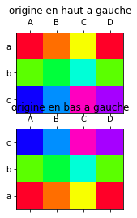

```python
#Exemple:
figure = plt.figure()
axes = figure.add_subplot(2, 1, 1)
mat = [[1, 2, 3, 1], [4, 5, 6, 4], [8, 7, 10, 9]]
axes.matshow(mat, cmap = plt.cm.gist_rainbow)
axes.set_xticks(range(4))
axes.set_xticklabels(['A', 'B', 'C', 'D'])
axes.set_yticks(range(3))
axes.set_yticklabels(['a', 'b', 'c'])
axes.set_title('origine en haut a gauche')
axes = figure.add_subplot(2, 1, 2)
axes.matshow(mat, origin = 'lower', cmap = plt.cm.gist_rainbow)
axes.set_xticks(range(4))
axes.set_xticklabels(['A', 'B', 'C', 'D'])
axes.set_yticks(range(3))
axes.set_yticklabels(['a', 'b', 'c'])
axes.set_title('origine en bas a gauche')
```

## Presentée par Bolares Kouame